# Midterm Presentation

11/25/2019

## Length of Stay

- I chose to predict the length of stay of a patient
- Broke up the target variable into over/under 4.5 days at the hospital
- Chose that split based on the national average

## Visualizing the Length of Stay

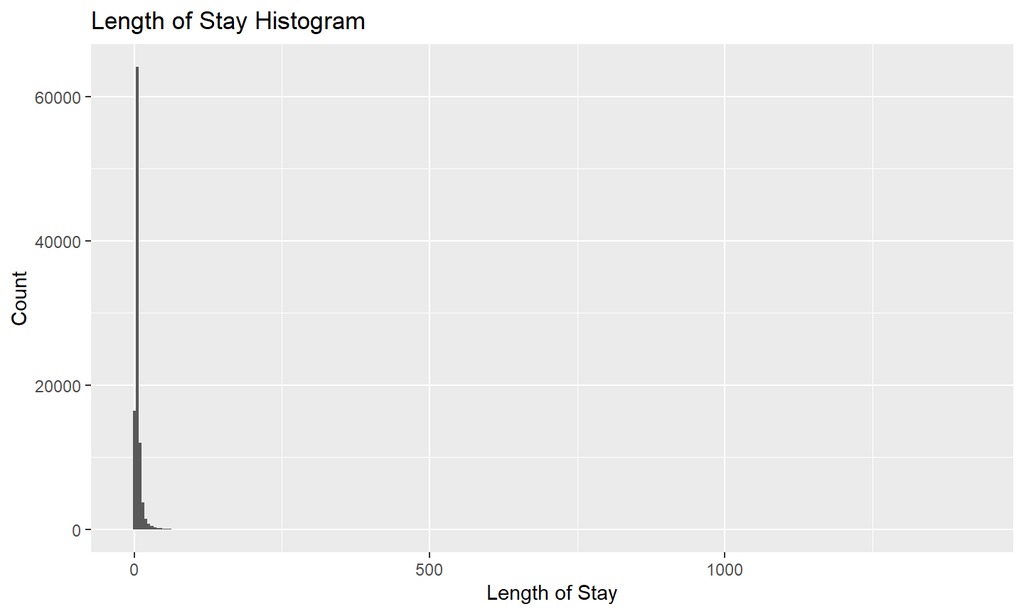

## Log Transformed Length of Stay

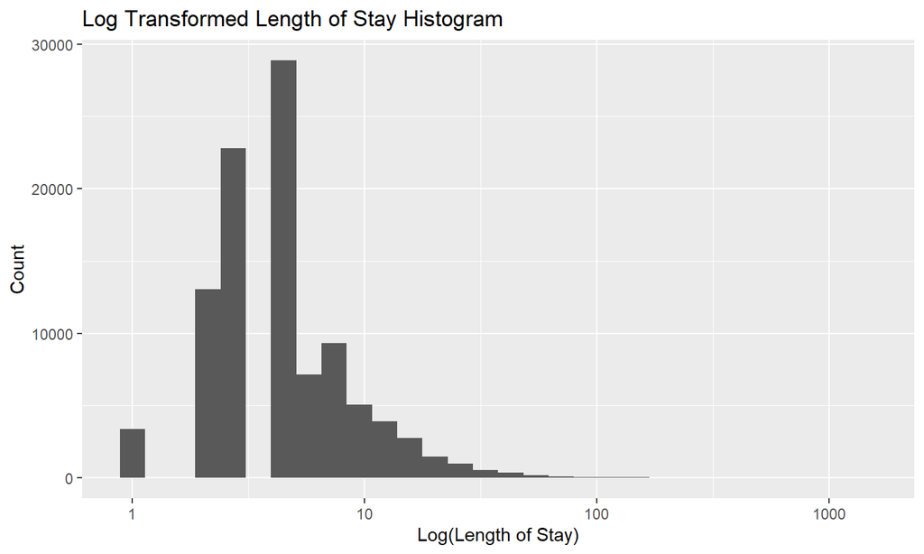

## Switched to Binary Length of Stay

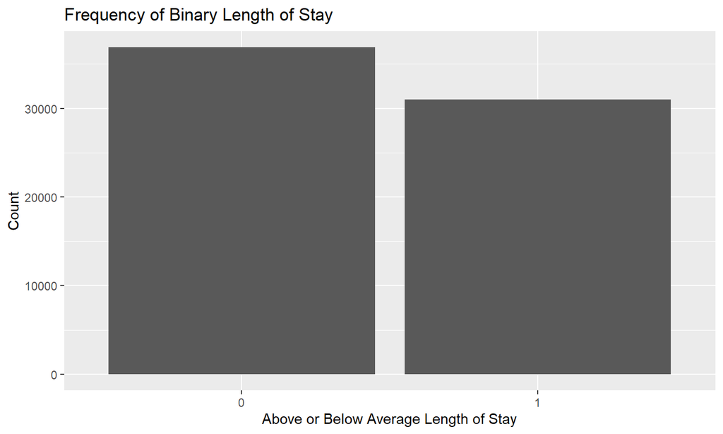

## Length of Stay by Provider

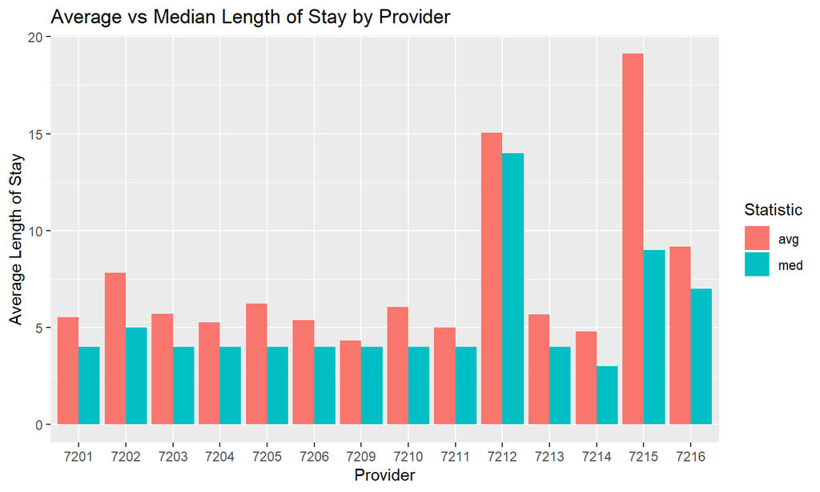

## Data Cleaning Methods

- Only used variables that would be known upon patient arrival
- Changed most of these to factors
- Did lots of mode imputation
- Left some nulls if the mode imputation was deemed unreliable
- Took only the first three characters of the diag_adm to remain broad
- Factor lumped to get rid of infrequent levels
- Filtered out incomplete cases after these steps

## Prepping for the Modeling

- Worked with 67,856 complete cases
- Split 70/30 Training/Testing
- Rebalanced the dataset despite a slight imbalance

## Model Results

- Random Forest: 0.6382
- Tuned Random Forest: 0.6394
- Decision Tree: 0.6164
- Tuned Decision Tree: 0.6037
- Adaboosted Decision Tree: 0.6279
- Neural Network: 0.6417
- Logistic Regression: 0.6422
- Strongest: Logistic Regression

## Future Studies

- Increase model complexity by increasing ranges the tuning grid would evaluate
- Improve imputation methods, would look into KNN
- Adjust the split for the target variable, too homogenous
- Increase the sample size of the data